# Homework 2

## Problem 1

We define the feature matrix as:

$$ \mathbf{X} = \left[\begin{array}{ccc} \text{cos}x & \text{sin}x & 1 \end{array}\right] \in \mathbb{R}^{n \times 3} , $$

and the parameter vector as:

$$ \mathbf{\theta} = \left[\begin{array}{ccc} \alpha & \beta & \gamma \end{array}\right] \in \mathbb{R}^{3}. $$

The function can be then rewritten as:

$$ \mathbf{y} = \mathbf{X}\mathbf{\theta}^\top. $$

To find the optimal estimate of $\theta$ (represented as $\hat{\mathbf{\theta}}$) as a least square problem, it can be formulated as:

$$ \hat{\mathbf{\theta}} = \underset{\theta}{\mathbf{\text{argmin}}} \left\| \mathbf{y} - \mathbf{X} \mathbf{\theta}^\top \right\|_2^2, $$

and according to the lecture note, the closed form of solution is given by

$$ \hat{\mathbf{\theta}} = (\mathbf{X}^{\top} \mathbf{X})^{-1} \mathbf{X}^{\top} \mathbf{y}. $$

## Problem 2

### 1.

Given $\mathbf{z} \sim \mathcal{N} (0, \sigma^2)$, we have $\mathbb{E} (\mathbf{z}) = 0$.

The closed form of solution of $\hat{\mathbf{\theta}}$ is given by

$$ \begin{alignat*}{2} \hat{\mathbf{\theta}} &= (\mathbf{X}^{\top} \mathbf{X})^{-1} \mathbf{X}^{\top} \mathbf{y} \\ &= (\mathbf{X}^{\top} \mathbf{X})^{-1} \mathbf{X}^{\top} (\mathbf{y}^* + \mathbf{z}) \\ &= (\mathbf{X}^{\top} \mathbf{X})^{-1} \mathbf{X}^{\top} \mathbf{y}^* + (\mathbf{X}^{\top} \mathbf{X})^{-1} \mathbf{X}^{\top} \mathbf{z} \\ &= \mathbf{\theta}^* + (\mathbf{X}^{\top} \mathbf{X})^{-1} \mathbf{X}^{\top} \mathbf{z}, \end{alignat*} $$

therefore, we can calculate the expectation of $\hat{\mathbf{\theta}}$ as:

$$ \begin{alignat*}{2} \mathbb{E}(\hat{\mathbf{\theta}}) &= \mathbb{E}(\mathbf{\theta}^* + (\mathbf{X}^{\top} \mathbf{X})^{-1} \mathbf{X}^{\top} \mathbf{z}) \\ &= \mathbf{\theta}^* + (\mathbf{X}^{\top} \mathbf{X})^{-1} \mathbf{X}^{\top} \mathbb{E}(\mathbf{z}), \end{alignat*} $$

recall that we have $\mathbb{E} (\mathbf{z}) = 0$, which leads to

$$ \mathbb{E}(\hat{\mathbf{\theta}}) = \mathbf{\theta}^*. $$

To further prove the next equation, firstly utilize the given hint to reformulate the left side of the equation

$$ \begin{alignat*}{2} \mathbb{E} (\left\| \mathbf{y}^* - \mathbf{X} \hat{\mathbf{\theta}} \right\|_2^2) &= \mathbb{E} (\left\| \mathbf{y}^* - \mathbf{X} \hat{\mathbf{\theta}} + \mathbf{X} \mathbf{\theta}^* - \mathbf{X} \mathbf{\theta}^* \right\|_2^2) \\ &= \mathbb{E} (\left\| (\mathbf{y}^* - \mathbf{X} \mathbf{\theta}^*) + (\mathbf{X} \mathbf{\theta}^* - \mathbf{X} \hat{\mathbf{\theta}}) \right\|_2^2) \\ &= \mathbb{E} (\left\| \mathbf{y}^* - \mathbf{X} \mathbf{\theta}^* \right\|_2^2 + \left\| \mathbf{X} \mathbf{\theta}^* - \mathbf{X} \hat{\mathbf{\theta}} \right\|_2^2 -2<\mathbf{y}^* - \mathbf{X} \mathbf{\theta}^*, \mathbf{X} \mathbf{\theta}^* - \mathbf{X} \hat{\mathbf{\theta}}>) \\ &= \mathbb{E} (\left\| \mathbf{y}^* - \mathbf{X} \mathbf{\theta}^* \right\|_2^2) + \mathbb{E} (\left\| \mathbf{X} \mathbf{\theta}^* - \mathbf{X} \hat{\mathbf{\theta}} \right\|_2^2) - 2\mathbb{E} ((\mathbf{y}^* - \mathbf{X} \mathbf{\theta}^*)^{\top} \cdot (\mathbf{X} \mathbf{\theta}^* - \mathbf{X} \hat{\mathbf{\theta}})) \\ &= \mathbb{E} (\left\| \mathbf{y}^* - \mathbf{X} \mathbf{\theta}^* \right\|_2^2) + \mathbb{E} (\left\| \mathbf{X} \mathbf{\theta}^* - \mathbf{X} \hat{\mathbf{\theta}} \right\|_2^2) - 2\mathbb{E} (\mathbf{y}^{* \top} \mathbf{X} \mathbf{\theta}^* - \mathbf{y}^{* \top} \mathbf{X} \hat{\mathbf{\theta}} - \mathbf{\theta}^{* \top} \mathbf{X}^{\top} \mathbf{X} \mathbf{\theta}^* + \mathbf{\theta}^{* \top} \mathbf{X}^{\top} \mathbf{X} \hat{\mathbf{\theta}}) \\ &= \mathbb{E} (\left\| \mathbf{y}^* - \mathbf{X} \mathbf{\theta}^* \right\|_2^2) + \mathbb{E} (\left\| \mathbf{X} \mathbf{\theta}^* - \mathbf{X} \hat{\mathbf{\theta}} \right\|_2^2) - 2(\mathbf{y}^{* \top} \mathbf{X} \mathbf{\theta}^* - \mathbf{y}^{* \top} \mathbf{X} \mathbb{E} (\hat{\mathbf{\theta}}) - \mathbf{\theta}^{* \top} \mathbf{X}^{\top} \mathbf{X} \mathbf{\theta}^* + \mathbf{\theta}^{* \top} \mathbf{X}^{\top} \mathbf{X} \mathbb{E} (\hat{\mathbf{\theta}})). \end{alignat*} $$

Recall that we have already prooven that $\mathbb{E}(\hat{\mathbf{\theta}}) = \mathbf{\theta}^*$, which makes that all the terms in the 3.rd bracket cancell each other, i.e.,

$$ \begin{alignat*}{2} \mathbb{E} (\left\| \mathbf{y}^* - \mathbf{X} \hat{\mathbf{\theta}} \right\|_2^2) &= \mathbb{E} (\left\| \mathbf{y}^* - \mathbf{X} \mathbf{\theta}^* \right\|_2^2) + \mathbb{E} (\left\| \mathbf{X} \mathbf{\theta}^* - \mathbf{X} \hat{\mathbf{\theta}} \right\|_2^2) \\ &= \left\| \mathbf{y}^* - \mathbb{E} (\mathbf{X} \mathbf{\theta}^*) \right\|_2^2 + \mathbb{E} (\left\| \mathbf{X} \hat{\mathbf{\theta}} - \mathbf{X} \mathbf{\theta}^* \right\|_2^2) \end{alignat*} $$

### 2.

Recall that we have derived the closed form of solution of $\hat{\mathbf{\theta}}$ as $\hat{\mathbf{\theta}} = \mathbf{\theta}^* + (\mathbf{X}^{\top} \mathbf{X})^{-1} \mathbf{X}^{\top} \mathbf{z}$, we can see that as $\mathbf{z} \sim \mathcal{N} (0, \sigma^2)$, therefore $\hat{\mathbf{\theta}}$ is also gaussian distributed, where the mean is by $\mathbf{\theta}^*$ shifted.

Then we only have to focus on the second term in $\hat{\mathbf{\theta}}$, i.e., $(\mathbf{X}^{\top} \mathbf{X})^{-1} \mathbf{X}^{\top} \mathbf{z}$. According to the task, given $\mathbf{v} \sim \mathcal{N}(0, \mathbf{\Sigma})$, then $\mathbf{A}\mathbf{v} \sim (0,\mathbf{A} \mathbf{\Sigma} \mathbf{A}^{\top})$. Let $\mathbf{A} = (\mathbf{X}^{\top} \mathbf{X})^{-1} \mathbf{X}^{\top}$ and $\mathbf{\Sigma} = \sigma^2$, then we have for the variance $$ \sigma^2 (\mathbf{X}^{\top} \mathbf{X})^{-1} \mathbf{X}^{\top} ((\mathbf{X}^{\top} \mathbf{X})^{-1} \mathbf{X}^{\top})^\top = \sigma^2 (\mathbf{X}^{\top} \mathbf{X})^{-1} $$

Therefore, $\hat{\mathbf{\theta}} \sim \mathcal{N} (\mathbf{\theta}^*, \sigma^2 (\mathbf{X}^{\top} \mathbf{X})^{-1})$

### 3.

For the given equation:

$$ \begin{alignat*}{2} \frac{1}{n}\mathbb{E} \left[ \left\| \mathbf{X} \hat{\mathbf{\theta}} - \mathbf{X} \mathbf{\theta}^* \right\|_2^2 \right] &= \sigma^2 \frac{d}{n} \\ \mathbb{E} \left[ \left\| \mathbf{X} \hat{\mathbf{\theta}} - \mathbf{X} \mathbf{\theta}^* \right\|_2^2 \right] &= \sigma^2 d. \end{alignat*} $$

Now, let's focus on the left side of the equation

$$ \begin{alignat*}{2} \text{left side} &= \mathbb{E} \left[ \left< \mathbf{X} \hat{\mathbf{\theta}} - \mathbf{X} \mathbf{\theta}^* , \mathbf{X} \hat{\mathbf{\theta}} - \mathbf{X} \mathbf{\theta}^* \right> \right] \\ &= \mathbb{E} \left[ \left( \mathbf{X} \left( \hat{\mathbf{\theta}} - \mathbf{\theta}^* \right) \right)^{\top} \left( \mathbf{X} \left( \hat{\mathbf{\theta}} - \mathbf{\theta}^* \right) \right) \right] \\ &= \mathbb{E} \left[ \left( \hat{\mathbf{\theta}} - \mathbf{\theta}^* \right)^{\top} \mathbf{X}^{\top} \mathbf{X} \left( \hat{\mathbf{\theta}} - \mathbf{\theta}^* \right) \right]. \\ \end{alignat*} $$

We know that the result of a inner product has to be a scalar, thus we have for the terms inside the expectation operator

$$ \left( \hat{\mathbf{\theta}} - \mathbf{\theta}^* \right)^{\top} \mathbf{X}^{\top} \mathbf{X} \left( \hat{\mathbf{\theta}} - \mathbf{\theta}^* \right) = \text{trace} \left( \left( \hat{\mathbf{\theta}} - \mathbf{\theta}^* \right)^{\top} \mathbf{X}^{\top} \mathbf{X} \left( \hat{\mathbf{\theta}} - \mathbf{\theta}^* \right) \right), $$

and therefore the expectation value can be calculated with the help of trace

$$ \mathbb{E} \left[ \left( \hat{\mathbf{\theta}} - \mathbf{\theta}^* \right)^{\top} \mathbf{X}^{\top} \mathbf{X} \left( \hat{\mathbf{\theta}} - \mathbf{\theta}^* \right) \right] = \mathbb{E} \left[ \text{trace} \left( \left( \hat{\mathbf{\theta}} - \mathbf{\theta}^* \right)^{\top} \mathbf{X}^{\top} \mathbf{X} \left( \hat{\mathbf{\theta}} - \mathbf{\theta}^* \right) \right) \right]. $$

Given $\mathbb{E} \left[ \text{trace} \left(\mathbf{A}\mathbf{B}\mathbf{C}\right) \right] = \mathbb{E} \left[ \text{trace} \left(\mathbf{C}\mathbf{A}\mathbf{B}\right) \right]$, let $\mathbf{A} = \left( \hat{\mathbf{\theta}} - \mathbf{\theta}^* \right)^{\top}$, $\mathbf{B} = \mathbf{X}^{\top} \mathbf{X}$, and $\mathbf{C} = \left( \hat{\mathbf{\theta}} - \mathbf{\theta}^* \right)$, we can re-formulate the right side of equation above as

$$ \mathbb{E} \left[ \text{trace} \left( \left( \hat{\mathbf{\theta}} - \mathbf{\theta}^* \right)^{\top} \mathbf{X}^{\top} \mathbf{X} \left( \hat{\mathbf{\theta}} - \mathbf{\theta}^* \right) \right) \right] = \mathbb{E} \left[ \text{trace} \left( \left( \hat{\mathbf{\theta}} - \mathbf{\theta}^* \right) \left( \hat{\mathbf{\theta}} - \mathbf{\theta}^* \right)^{\top} \mathbf{X}^{\top} \mathbf{X} \right) \right] $$

and according to $\mathbb{E} \left[ \text{trace} \left( \mathbf{A} \right) \right] = \text{trace} \left( \mathbb{E} \left[ \mathbf{A} \right] \right)$, the equation can be further rewritten as:

$$ \begin{alignat*}{2} \mathbb{E} \left[ \text{trace} \left( \left( \hat{\mathbf{\theta}} - \mathbf{\theta}^* \right) \left( \hat{\mathbf{\theta}} - \mathbf{\theta}^* \right)^{\top} \mathbf{X}^{\top} \mathbf{X} \right) \right] &= \text{trace} \left( \mathbb{E} \left[ \left( \hat{\mathbf{\theta}} - \mathbf{\theta}^* \right) \left( \hat{\mathbf{\theta}} - \mathbf{\theta}^* \right)^{\top} \mathbf{X}^{\top} \mathbf{X} \right] \right) \\ &= \text{trace} \left( \mathbb{E} \left[ \left( \hat{\mathbf{\theta}} - \mathbf{\theta}^* \right) \left( \hat{\mathbf{\theta}} - \mathbf{\theta}^* \right)^{\top} \right] \mathbf{X}^{\top} \mathbf{X} \right) \end{alignat*} $$

we can see that the term $\mathbb{E} \left[ \left( \hat{\mathbf{\theta}} - \mathbf{\theta}^* \right) \left( \hat{\mathbf{\theta}} - \mathbf{\theta}^* \right)^{\top} \right]$ is the covariance matrix of $\hat{\mathbf{\theta}}$ since that $\mathbb{E} \left[ \hat{\mathbf{\theta}} \right] = \mathbf{\theta}^*$, and we also had $\hat{\mathbf{\theta}} \sim \mathcal{N} \left( \mathbf{\theta}^*, \sigma^2 \left( \mathbf{X}^{\top} \mathbf{X} \right)^{-1} \right)$, therefore, $\mathbb{E} \left[ \left( \hat{\mathbf{\theta}} - \mathbf{\theta}^* \right) \left( \hat{\mathbf{\theta}} - \mathbf{\theta}^* \right)^{\top} \right] = \sigma^2 \left( \mathbf{X}^{\top} \mathbf{X} \right)^{-1}$. So for the right side of the equation above we have:

$$ \begin{alignat*}{2} \text{trace} \left( \mathbb{E} \left[ \left( \hat{\mathbf{\theta}} - \mathbf{\theta}^* \right) \left( \hat{\mathbf{\theta}} - \mathbf{\theta}^* \right)^{\top} \right] \mathbf{X}^{\top} \mathbf{X} \right) &= \text{trace} \left( \sigma^2 \left( \mathbf{X}^{\top} \mathbf{X} \right)^{-1} \mathbf{X}^{\top} \mathbf{X} \right) \\ &= \sigma^2 \text{trace} \left( \mathbf{I} \right) \\ &= \sigma^2 d. \end{alignat*} $$

It is proven that

$$ \mathbb{E} \left[ \left\| \mathbf{X} \hat{\mathbf{\theta}} - \mathbf{X} \mathbf{\theta}^* \right\|_2^2 \right] = \mathbb{E} \left[ \left< \mathbf{X} \hat{\mathbf{\theta}} - \mathbf{X} \mathbf{\theta}^* , \mathbf{X} \hat{\mathbf{\theta}} - \mathbf{X} \mathbf{\theta}^* \right> \right] = \sigma^2 d, $$

therefore

$$ \frac{1}{n} \mathbb{E} \left[ \left\| \mathbf{X} \hat{\mathbf{\theta}} - \mathbf{X} \mathbf{\theta}^* \right\|_2^2 \right] = \sigma^2 \frac{d}{n}. $$

### 4.

Given assumption that the underlying function is linear, i.e., all the terms with order higher than 1 in the feature vector should be multiplied by 0 in the parameter vector, which gives us the parameter vector $\mathbf{\theta}$ as $\mathbf{\theta} = \left[ \begin{array}{ccc} \theta_0 & \theta_1 & \mathbf{0}_{D-1} \end{array} \right] \in \mathbb{R}^{D+1}$.

And $\left\| \mathbf{y}^* - \mathbf{X} \mathbf{\theta}^* \right\|_2 = 0$.

For this subtask we have $d = D+1$, and according to previous task, where we proven that $\frac{1}{n} \mathbb{E} \left[ \left\| \mathbf{X} \hat{\mathbf{\theta}} - \mathbf{X} \mathbf{\theta}^* \right\|_2^2 \right] = \sigma^2 \frac{d}{n}$, we have

$$ \frac{1}{n} \mathbb{E} \left[ \left\| \mathbf{y}^* - \mathbf{X} \hat{\mathbf{\theta}} \right\|_2^2 \right] = \sigma^2 \frac{D+1}{n}. $$

$\sigma^2 \frac{D+1}{n}$ should be upper bounded by $\epsilon$, which means

$$ \sigma^2 \frac{D+1}{n} \le \epsilon ~~~~~~ \Rightarrow ~~~~~~ n \ge \sigma^2 \frac{D+1}{\epsilon} $$

### 5.

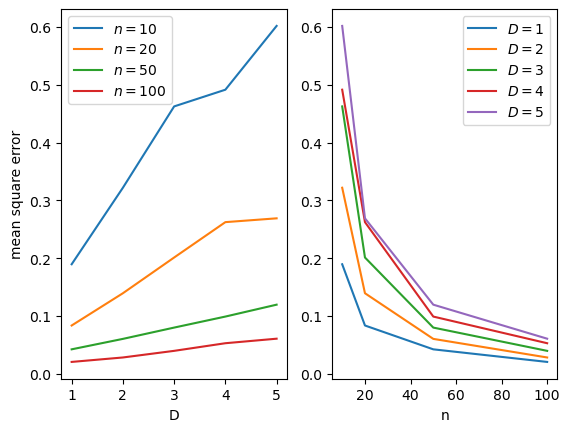

```python
import numpy as np
from matplotlib import pyplot as plt

def pred_error(n, D):
  alpha = np.random.uniform(-1, 1, n)
  y_star = alpha + 1

  z = np.random.normal(0, 1, n)
  y = y_star + z

  # use numpy.polyfit to get the coefficients of the fitted polynomial
  params = np.polyfit(alpha, y, D)
  # use numpy.poly1d to generate the fitted polynomial
  poly = np.poly1d(params)

  pred_error = ((y_star - poly(alpha))**2).mean()

  return pred_error


ns = np.array([10, 20, 50, 100])
Ds = np.array([1, 2, 3, 4, 5])

error = np.zeros((ns.size, Ds.size))

# iterate over all combinations of n and D, for each combination calculate 10 times and average the error
for i in range(0, ns.size):
  for j in range(0, Ds.size):
    for k in range (100):
      error[i, j] += pred_error(ns[i], Ds[j])/100

plt.subplot(1, 2, 1)
for i in range(0, ns.size):
  plt.plot(Ds, error[i, :], label='$n=%d$' % ns[i])
plt.title("")
plt.xlabel("D")
plt.ylabel("mean square error")
plt.legend()

plt.subplot(1, 2, 2)
for i in range(0, Ds.size):
  plt.plot(ns, error[:, i], label='$D=%d$' % Ds[i])
plt.title("")
plt.xlabel("n")
plt.legend()
```